# 2023MCS120003_miniproject

Sumod Sethumadhavan

11/11/2023

## R Markdown

```r
# Loading the datasets

# Bangalore
bangalore_df <- read.csv("d1/Bangalore_1990_2022_BangaloreCity.csv")

# Chennai
chennai_df <- read.csv("d1/Chennai_1990_2022_Madras.csv")

# Delhi
delhi_df <- read.csv("d1/Delhi_NCR_1990_2022_Safdarjung.csv")

# Lucknow
lucknow_df <- read.csv("d1/Lucknow_1990_2022.csv")

# Mumbai
mumbai_df <- read.csv("d1/Mumbai_1990_2022_Santacruz.csv")

# Rajasthan (Jodhpur)
rajasthan_df <- read.csv("d1/Rajasthan_1990_2022_Jodhpur.csv")

# Bhubaneswar
bhubaneswar_df <- read.csv("d1/weather_Bhubhneshwar_1990_2022.csv")

# Rourkela
rourkela_df <- read.csv("d1/weather_Rourkela_2021_2022.csv")

# Load the Station GeoLocation data
station_geo_df <- read.csv("d1/Station_GeoLocation_Longitute_Latitude_Elevation_EPSG_4326.csv")

# Preprocessing the Bangalore dataset
library(dplyr)
# Convert date column to Date format
bangalore_df$time <- as.Date(bangalore_df$time, format = "%d-%m-%Y")

# Filter data for 2015-2020
bangalore_df <- bangalore_df %>%
                filter(format(time, "%Y") >= "2015" & format(time, "%Y") <= "2020")


#chennai
chennai_df$time <- as.Date(chennai_df$time, format = "%d-%m-%Y")
chennai_df <- chennai_df %>%
              filter(format(time, "%Y") >= "2015" & format(time, "%Y") <= "2020")

#Delhi
delhi_df$time <- as.Date(delhi_df$time, format = "%d-%m-%Y")
delhi_df <- delhi_df %>%
            filter(format(time, "%Y") >= "2015" & format(time, "%Y") <= "2020")

#Lucknow
lucknow_df$time <- as.Date(lucknow_df$time, format = "%d-%m-%Y")
lucknow_df <- lucknow_df %>%
              filter(format(time, "%Y") >= "2015" & format(time, "%Y") <= "2020")

#MUmbai
mumbai_df$time <- as.Date(mumbai_df$time, format = "%d-%m-%Y")
mumbai_df <- mumbai_df %>%
              filter(format(time, "%Y") >= "2015" & format(time, "%Y") <= "2020")

#rajasthan
rajasthan_df$time <- as.Date(rajasthan_df$time, format = "%d-%m-%Y")
rajasthan_df <- rajasthan_df %>%
                filter(format(time, "%Y") >= "2015" & format(time, "%Y") <= "2020")

#bhub
bhubaneswar_df$time <- as.Date(bhubaneswar_df$time, format = "%d-%m-%Y")
bhubaneswar_df <- bhubaneswar_df %>%
                  filter(format(time, "%Y") >= "2015" & format(time, "%Y") <= "2020")

#rourkela
rourkela_df$time <- as.Date(rourkela_df$time, format = "%d-%m-%Y")
rourkela_df <- rourkela_df %>%
               filter(format(time, "%Y") >= "2015" & format(time, "%Y") <= "2020")

# Handling missing values in Bangalore dataset
bangalore_df <- bangalore_df %>%
                mutate(tavg = ifelse(is.na(tavg), mean(tavg, na.rm = TRUE), tavg),
                       tmin = ifelse(is.na(tmin), mean(tmin, na.rm = TRUE), tmin),
                       tmax = ifelse(is.na(tmax), mean(tmax, na.rm = TRUE), tmax),
                       prcp = ifelse(is.na(prcp), mean(prcp, na.rm = TRUE), prcp))

# Chennai
chennai_df <- chennai_df %>%
              mutate(tavg = ifelse(is.na(tavg), mean(tavg, na.rm = TRUE), tavg),
                     tmin = ifelse(is.na(tmin), mean(tmin, na.rm = TRUE), tmin),
                     tmax = ifelse(is.na(tmax), mean(tmax, na.rm = TRUE), tmax),
                     prcp = ifelse(is.na(prcp), mean(prcp, na.rm = TRUE), prcp))

#Delhi

delhi_df <- delhi_df %>%
            mutate(tavg = ifelse(is.na(tavg), mean(tavg, na.rm = TRUE), tavg),
                   tmin = ifelse(is.na(tmin), mean(tmin, na.rm = TRUE), tmin),
                   tmax = ifelse(is.na(tmax), mean(tmax, na.rm = TRUE), tmax),
                   prcp = ifelse(is.na(prcp), mean(prcp, na.rm = TRUE), prcp))

# Lucknow
lucknow_df <- lucknow_df %>%
              mutate(tavg = ifelse(is.na(tavg), mean(tavg, na.rm = TRUE), tavg),
                     tmin = ifelse(is.na(tmin), mean(tmin, na.rm = TRUE), tmin),
                     tmax = ifelse(is.na(tmax), mean(tmax, na.rm = TRUE), tmax),
                     prcp = ifelse(is.na(prcp), mean(prcp, na.rm = TRUE), prcp))

#Mumbai Dataset
mumbai_df <- mumbai_df %>%
             mutate(tavg = ifelse(is.na(tavg), mean(tavg, na.rm = TRUE), tavg),
                    tmin = ifelse(is.na(tmin), mean(tmin, na.rm = TRUE), tmin),
                    tmax = ifelse(is.na(tmax), mean(tmax, na.rm = TRUE), tmax),
                    prcp = ifelse(is.na(prcp), mean(prcp, na.rm = TRUE), prcp))

#rajasthan
rajasthan_df <- rajasthan_df %>%
                mutate(tavg = ifelse(is.na(tavg), mean(tavg, na.rm = TRUE), tavg),
                       tmin = ifelse(is.na(tmin), mean(tmin, na.rm = TRUE), tmin),
                       tmax = ifelse(is.na(tmax), mean(tmax, na.rm = TRUE), tmax),
                       prcp = ifelse(is.na(prcp), mean(prcp, na.rm = TRUE), prcp))

#bhub
bhubaneswar_df <- bhubaneswar_df %>%
                  mutate(tavg = ifelse(is.na(tavg), mean(tavg, na.rm = TRUE), tavg),
                         tmin = ifelse(is.na(tmin), mean(tmin, na.rm = TRUE), tmin),
                         tmax = ifelse(is.na(tmax), mean(tmax, na.rm = TRUE), tmax),
                         prcp = ifelse(is.na(prcp), mean(prcp, na.rm = TRUE), prcp))

#rourkela
rourkela_df <- rourkela_df %>%
               mutate(tavg = ifelse(is.na(tavg), mean(tavg, na.rm = TRUE), tavg),
                      tmin = ifelse(is.na(tmin), mean(tmin, na.rm = TRUE), tmin),
                      tmax = ifelse(is.na(tmax), mean(tmax, na.rm = TRUE), tmax),
                      prcp = ifelse(is.na(prcp), mean(prcp, na.rm = TRUE), prcp))
```

#### Summary Statistics:

```r
# Example for Bangalore
summary_stats_bangalore <- bangalore_df %>%
                           summarise(Mean_Tavg = mean(tavg, na.rm = TRUE),
                                     Median_Tavg = median(tavg, na.rm = TRUE),
                                     SD_Tavg = sd(tavg, na.rm = TRUE),
                                     Mean_Prcp = mean(prcp, na.rm = TRUE),
                                     Median_Prcp = median(prcp, na.rm = TRUE),
                                     SD_Prcp = sd(prcp, na.rm = TRUE))

summary_stats_bangalore
```

```
##   Mean_Tavg Median_Tavg  SD_Tavg Mean_Prcp Median_Prcp  SD_Prcp
## 1  24.18695        23.8 2.226738  5.930541    5.930541 8.966999
```

```r
#chennai

summary_stats_chennai <- chennai_df %>%
                         summarise(Mean_Tavg = mean(tavg, na.rm = TRUE),
                                   Median_Tavg = median(tavg, na.rm = TRUE),
                                   SD_Tavg = sd(tavg, na.rm = TRUE),
                                   Mean_Prcp = mean(prcp, na.rm = TRUE),
                                   Median_Prcp = median(prcp, na.rm = TRUE),
                                   SD_Prcp = sd(prcp, na.rm = TRUE))

# Delhi
summary_stats_delhi <- delhi_df %>%
                       summarise(Mean_Tavg = mean(tavg, na.rm = TRUE),
                                 Median_Tavg = median(tavg, na.rm = TRUE),
                                 SD_Tavg = sd(tavg, na.rm = TRUE),
                                 Mean_Prcp = mean(prcp, na.rm = TRUE),
                                 Median_Prcp = median(prcp, na.rm = TRUE),
                                 SD_Prcp = sd(prcp, na.rm = TRUE))

#Lucknow
summary_stats_lucknow <- lucknow_df %>%
                         summarise(Mean_Tavg = mean(tavg, na.rm = TRUE),
                                   Median_Tavg = median(tavg, na.rm = TRUE),
                                   SD_Tavg = sd(tavg, na.rm = TRUE),
                                   Mean_Prcp = mean(prcp, na.rm = TRUE),
                                   Median_Prcp = median(prcp, na.rm = TRUE),
                                   SD_Prcp = sd(prcp, na.rm = TRUE))
#Mumbai
summary_stats_mumbai <- mumbai_df %>%
                        summarise(Mean_Tavg = mean(tavg, na.rm = TRUE),
                                  Median_Tavg = median(tavg, na.rm = TRUE),
                                  SD_Tavg = sd(tavg, na.rm = TRUE),
                                  Mean_Prcp = mean(prcp, na.rm = TRUE),
                                  Median_Prcp = median(prcp, na.rm = TRUE),
                                  SD_Prcp = sd(prcp, na.rm = TRUE))

#Rajasthan
summary_stats_rajasthan <- rajasthan_df %>%
                           summarise(Mean_Tavg = mean(tavg, na.rm = TRUE),
                                     Median_Tavg = median(tavg, na.rm = TRUE),
                                     SD_Tavg = sd(tavg, na.rm = TRUE),
                                     Mean_Prcp = mean(prcp, na.rm = TRUE),
                                     Median_Prcp = median(prcp, na.rm = TRUE),
                                     SD_Prcp = sd(prcp, na.rm = TRUE))

#Bhubaneshwar
summary_stats_bhubaneswar <- bhubaneswar_df %>%
                             summarise(Mean_Tavg = mean(tavg, na.rm = TRUE),
                                       Median_Tavg = median(tavg, na.rm = TRUE),
                                       SD_Tavg = sd(tavg, na.rm = TRUE),
                                       Mean_Prcp = mean(prcp, na.rm = TRUE),
                                       Median_Prcp = median(prcp, na.rm = TRUE),
                                       SD_Prcp = sd(prcp, na.rm = TRUE))
#Rourkela
summary_stats_rourkela <- rourkela_df %>%
                          summarise(Mean_Tavg = mean(tavg, na.rm = TRUE),
                                    Median_Tavg = median(tavg, na.rm = TRUE),
                                    SD_Tavg = sd(tavg, na.rm = TRUE),
                                    Mean_Prcp = mean(prcp, na.rm = TRUE),
                                    Median_Prcp = median(prcp, na.rm = TRUE),
                                    SD_Prcp = sd(prcp, na.rm = TRUE))
```

## Trend Analysis

### Temperature and Precipitation Trends Over Time

```r
library(ggplot2)

# Function to calculate annual trends
calculate_annual_trends <- function(df) {
  df %>%
    group_by(Year = format(time, "%Y")) %>%
    summarise(Mean_Tavg = mean(tavg, na.rm = TRUE),
              Total_Prcp = sum(prcp, na.rm = TRUE))
}
```

## Trend Analysis for Each City

### Bangalore Trend Analysis

```
## `geom_line()`: Each group consists of only one observation.
## ℹ Do you need to adjust the group aesthetic?
```

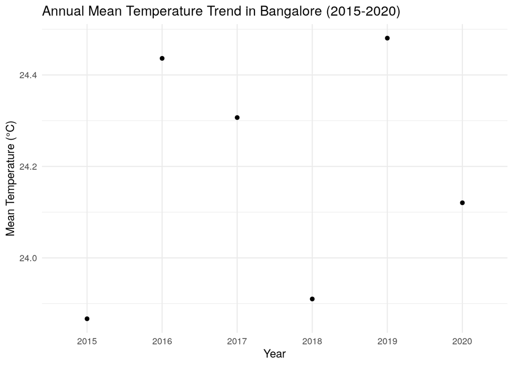

```r
# Annual trends for Bangalore
annual_trends_bangalore <- bangalore_df %>%
                           group_by(Year = format(time, "%Y")) %>%
                           summarise(Mean_Tavg = mean(tavg, na.rm = TRUE),
                                     Total_Prcp = sum(prcp, na.rm = TRUE))

# Temperature Trend Plot for Bangalore
ggplot(annual_trends_bangalore, aes(x = Year, y = Mean_Tavg)) +
    geom_point() +
    geom_line() +
    labs(title = "Annual Mean Temperature Trend in Bangalore (2015-2020)",
         x = "Year",
         y = "Mean Temperature (°C)") +
    theme_minimal()
```

```
## `geom_line()`: Each group consists of only one observation.
## ℹ Do you need to adjust the group aesthetic?
```

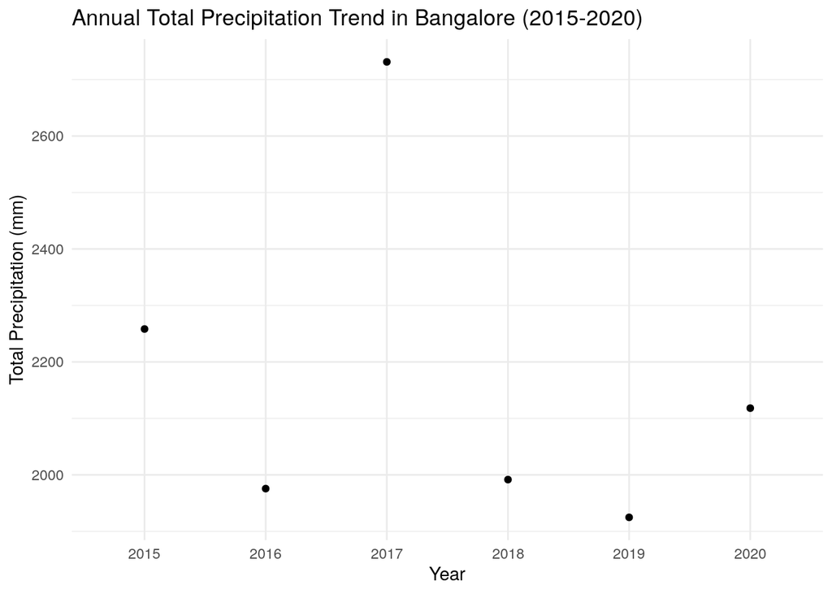

```r
# Precipitation Trend Plot for Bangalore
ggplot(annual_trends_bangalore, aes(x = Year, y = Total_Prcp)) +
    geom_point() +
    geom_line() +
    labs(title = "Annual Total Precipitation Trend in Bangalore (2015-2020)",
         x = "Year",
         y = "Total Precipitation (mm)") +
    theme_minimal()
```

```
## `geom_line()`: Each group consists of only one observation.
## ℹ Do you need to adjust the group aesthetic?
```

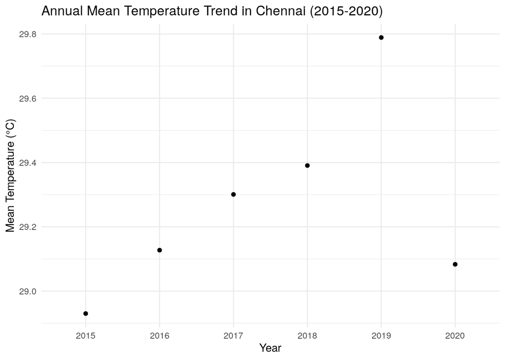

```r
# Annual trends for Chennai
annual_trends_chennai <- chennai_df %>%
                         group_by(Year = format(time, "%Y")) %>%
                         summarise(Mean_Tavg = mean(tavg, na.rm = TRUE),
                                   Total_Prcp = sum(prcp, na.rm = TRUE))

# Temperature Trend Plot for Chennai
ggplot(annual_trends_chennai, aes(x = Year, y = Mean_Tavg)) +
    geom_point() +
    geom_line() +
    labs(title = "Annual Mean Temperature Trend in Chennai (2015-2020)",
         x = "Year",
         y = "Mean Temperature (°C)") +
    theme_minimal()
```

```
## `geom_line()`: Each group consists of only one observation.
## ℹ Do you need to adjust the group aesthetic?
```

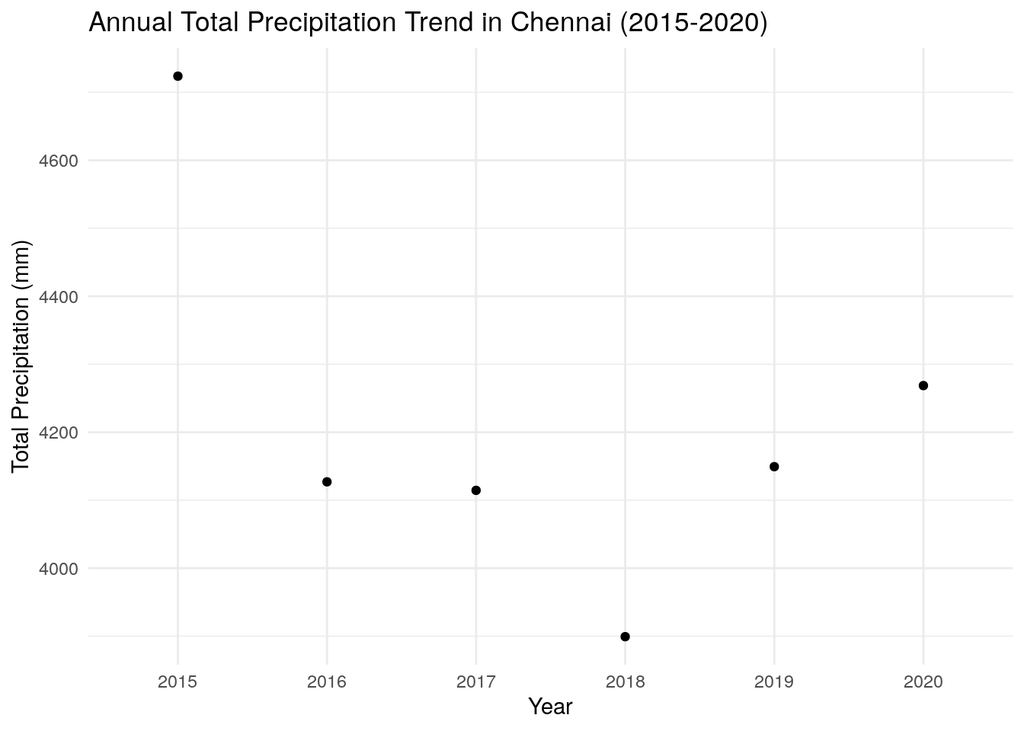

```r
# Precipitation Trend Plot for Chennai
ggplot(annual_trends_chennai, aes(x = Year, y = Total_Prcp)) +
    geom_point() +
    geom_line() +
    labs(title = "Annual Total Precipitation Trend in Chennai (2015-2020)",
         x = "Year",
         y = "Total Precipitation (mm)") +
    theme_minimal()
```

```
## `geom_line()`: Each group consists of only one observation.
## ℹ Do you need to adjust the group aesthetic?
```

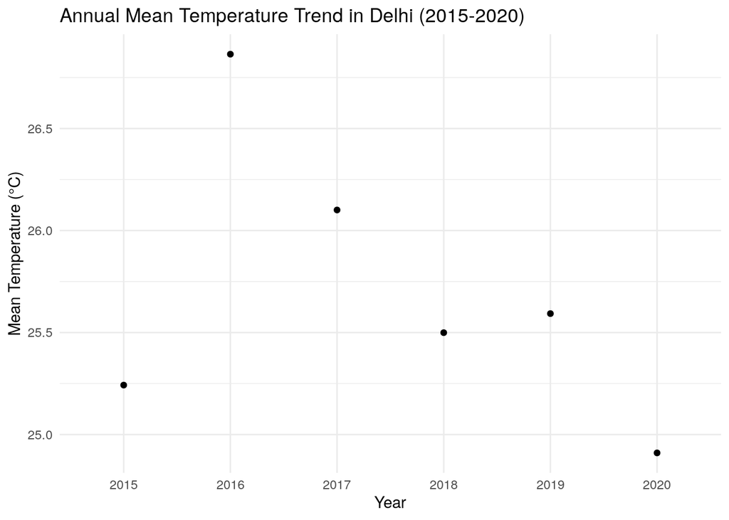

```r
# Annual trends for Delhi
annual_trends_delhi <- delhi_df %>%
                       group_by(Year = format(time, "%Y")) %>%
                       summarise(Mean_Tavg = mean(tavg, na.rm = TRUE),
                                 Total_Prcp = sum(prcp, na.rm = TRUE))

# Temperature Trend Plot for Delhi
ggplot(annual_trends_delhi, aes(x = Year, y = Mean_Tavg)) +
    geom_point() +
    geom_line() +
    labs(title = "Annual Mean Temperature Trend in Delhi (2015-2020)",
         x = "Year",
         y = "Mean Temperature (°C)") +
    theme_minimal()
```

```
## `geom_line()`: Each group consists of only one observation.
## ℹ Do you need to adjust the group aesthetic?
```

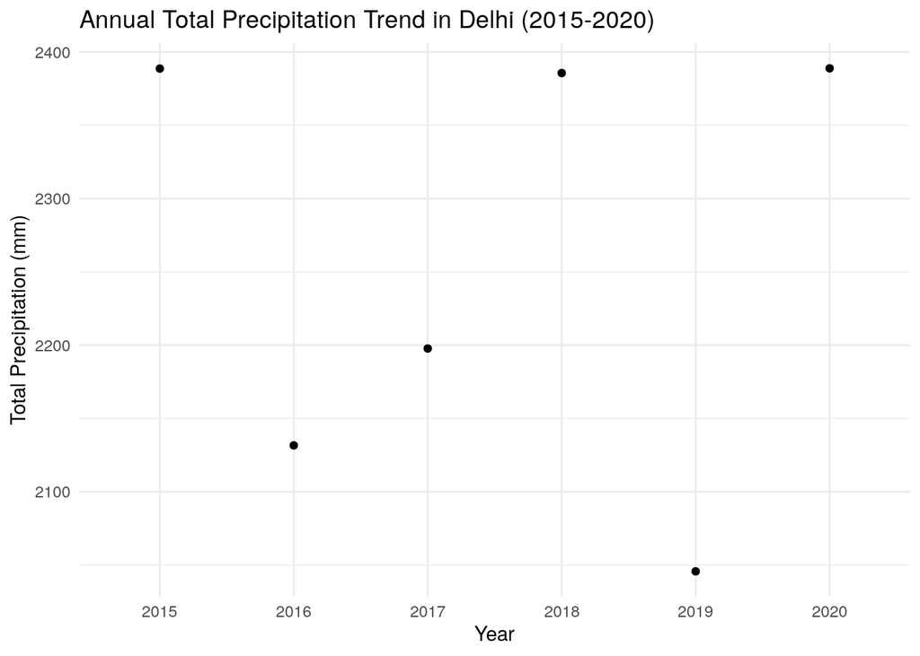

```r
# Precipitation Trend Plot for Delhi
ggplot(annual_trends_delhi, aes(x = Year, y = Total_Prcp)) +
    geom_point() +
    geom_line() +
    labs(title = "Annual Total Precipitation Trend in Delhi (2015-2020)",
         x = "Year",
         y = "Total Precipitation (mm)") +
    theme_minimal()
```

```
## `geom_line()`: Each group consists of only one observation.
## ℹ Do you need to adjust the group aesthetic?
```

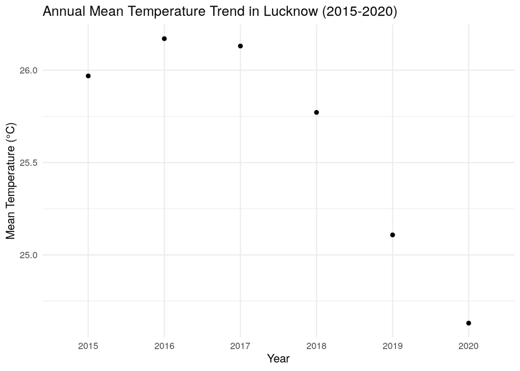

```r
# Annual trends for Lucknow
annual_trends_lucknow <- lucknow_df %>%
                         group_by(Year = format(time, "%Y")) %>%
                         summarise(Mean_Tavg = mean(tavg, na.rm = TRUE),
                                   Total_Prcp = sum(prcp, na.rm = TRUE))

# Temperature Trend Plot for Lucknow
ggplot(annual_trends_lucknow, aes(x = Year, y = Mean_Tavg)) +
    geom_point() +
    geom_line() +
    labs(title = "Annual Mean Temperature Trend in Lucknow (2015-2020)",
         x = "Year",
         y = "Mean Temperature (°C)") +
    theme_minimal()
```

```
## `geom_line()`: Each group consists of only one observation.
## ℹ Do you need to adjust the group aesthetic?
```

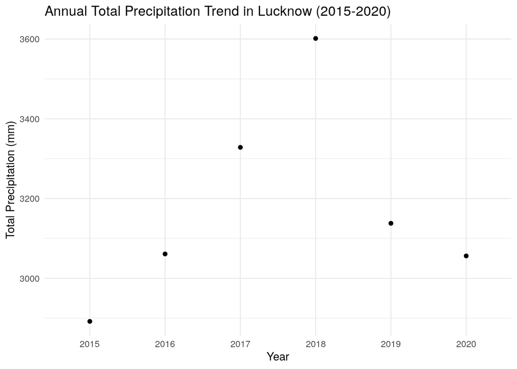

```r
# Precipitation Trend Plot for Lucknow
ggplot(annual_trends_lucknow, aes(x = Year, y = Total_Prcp)) +
    geom_point() +
    geom_line() +
    labs(title = "Annual Total Precipitation Trend in Lucknow (2015-2020)",
         x = "Year",
         y = "Total Precipitation (mm)") +
    theme_minimal()
```

```
## `geom_line()`: Each group consists of only one observation.
## ℹ Do you need to adjust the group aesthetic?
```

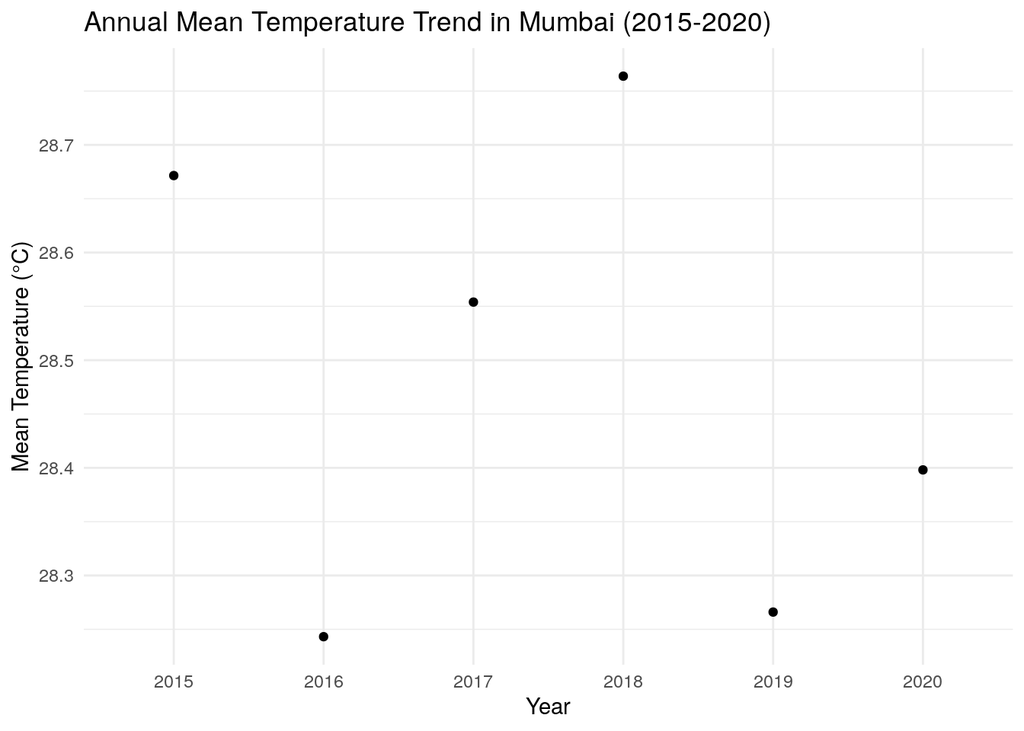

```r
# Annual trends for Mumbai
annual_trends_mumbai <- mumbai_df %>%
                        group_by(Year = format(time, "%Y")) %>%
                        summarise(Mean_Tavg = mean(tavg, na.rm = TRUE),
                                  Total_Prcp = sum(prcp, na.rm = TRUE))

# Temperature Trend Plot for Mumbai
ggplot(annual_trends_mumbai, aes(x = Year, y = Mean_Tavg)) +
    geom_point() +
    geom_line() +
    labs(title = "Annual Mean Temperature Trend in Mumbai (2015-2020)",
         x = "Year",
         y = "Mean Temperature (°C)") +
    theme_minimal()
```

```
## `geom_line()`: Each group consists of only one observation.
## ℹ Do you need to adjust the group aesthetic?
```

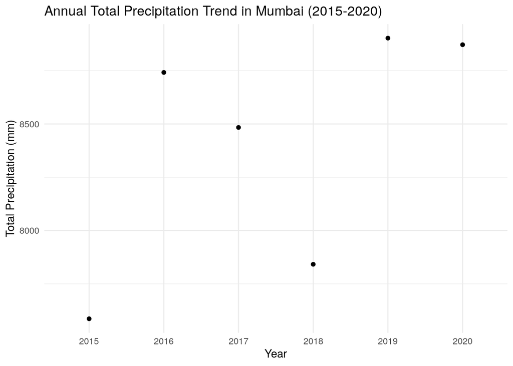

```r
# Precipitation Trend Plot for Mumbai
ggplot(annual_trends_mumbai, aes(x = Year, y = Total_Prcp)) +
    geom_point() +
    geom_line() +
    labs(title = "Annual Total Precipitation Trend in Mumbai (2015-2020)",
         x = "Year",
         y = "Total Precipitation (mm)") +
    theme_minimal()
```

```
## `geom_line()`: Each group consists of only one observation.
## ℹ Do you need to adjust the group aesthetic?
```

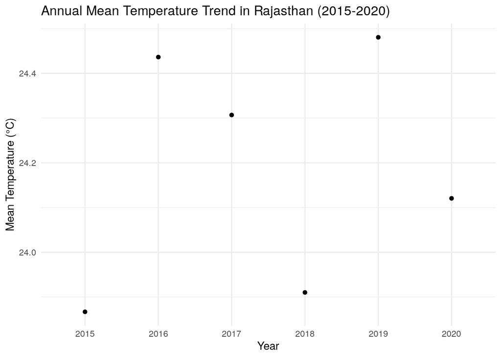

```r
# Annual trends for Rajasthan
annual_trends_rajasthan <- rajasthan_df %>%
                           group_by(Year = format(time, "%Y")) %>%
                           summarise(Mean_Tavg = mean(tavg, na.rm = TRUE),
                                     Total_Prcp = sum(prcp, na.rm = TRUE))

# Temperature Trend Plot for Rajasthan
ggplot(annual_trends_rajasthan, aes(x = Year, y = Mean_Tavg)) +
    geom_point() +
    geom_line() +
    labs(title = "Annual Mean Temperature Trend in Rajasthan (2015-2020)",
         x = "Year",
         y = "Mean Temperature (°C)") +
    theme_minimal()
```

```
## `geom_line()`: Each group consists of only one observation.
## ℹ Do you need to adjust the group aesthetic?
```

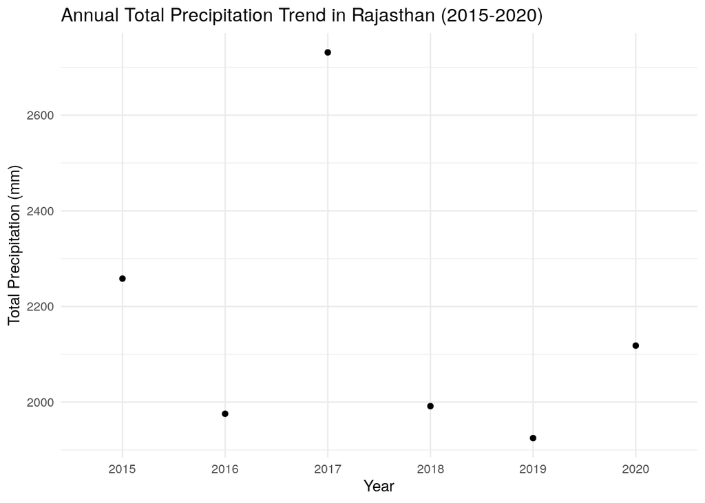

```r
# Precipitation Trend Plot for Rajasthan
ggplot(annual_trends_rajasthan, aes(x = Year, y = Total_Prcp)) +
    geom_point() +
    geom_line() +
    labs(title = "Annual Total Precipitation Trend in Rajasthan (2015-2020)",
         x = "Year",
         y = "Total Precipitation (mm)") +
    theme_minimal()
```

```r
# Reload the dataset
bhubaneswar_df <- read.csv("d1/weather_Bhubhneshwar_1990_2022.csv")

# Convert 'time' column to Date format (if not already done)
bhubaneswar_df$time <- as.Date(bhubaneswar_df$time, format = "%Y-%m-%d")

# Extract the year from the date and create a new column
bhubaneswar_df$Year <- format(bhubaneswar_df$time, "%Y")

# Convert the Year column to numeric
bhubaneswar_df$Year <- as.numeric(bhubaneswar_df$Year)

# Filter data for 2015-2020
bhubaneswar_2015_2020 <- bhubaneswar_df %>%
                         filter(Year >= 2015 & Year <= 2020)

# View the first few rows
head(bhubaneswar_2015_2020)
```

```
##         time tavg tmin tmax prcp snow wdir wspd wpgt pres tsun Year
## 1 2015-01-01 19.9   NA 21.6  5.1   NA   NA   NA   NA   NA   NA 2015
## 2 2015-01-02 23.2   NA 26.1 13.0   NA   NA   NA   NA   NA   NA 2015
## 3 2015-01-03 24.9   NA 29.2  0.3   NA   NA   NA   NA   NA   NA 2015
## 4 2015-01-04 24.4   NA 27.7  0.0   NA   NA   NA   NA   NA   NA 2015
## 5 2015-01-05 22.4   NA 28.1   NA   NA   NA   NA   NA   NA   NA 2015
## 6 2015-01-06 20.5   NA 27.8   NA   NA   NA   NA   NA   NA   NA 2015
```

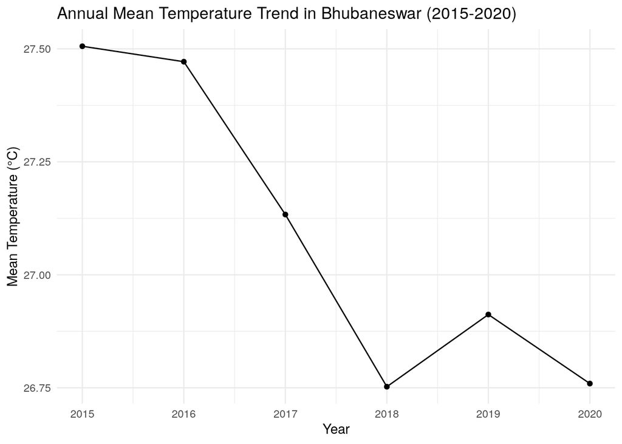

```r
# Annual trends for Bhubaneswar
annual_trends_bhubaneswar <- bhubaneswar_2015_2020 %>%
                             group_by(Year) %>%
                             summarise(Mean_Tavg = mean(tavg, na.rm = TRUE),
                                       Total_Prcp = sum(prcp, na.rm = TRUE))

# Temperature Trend Plot for Bhubaneswar
ggplot(annual_trends_bhubaneswar, aes(x = Year, y = Mean_Tavg)) +
    geom_point() +
    geom_line() +
    labs(title = "Annual Mean Temperature Trend in Bhubaneswar (2015-2020)",
         x = "Year",
         y = "Mean Temperature (°C)") +
    theme_minimal()
```

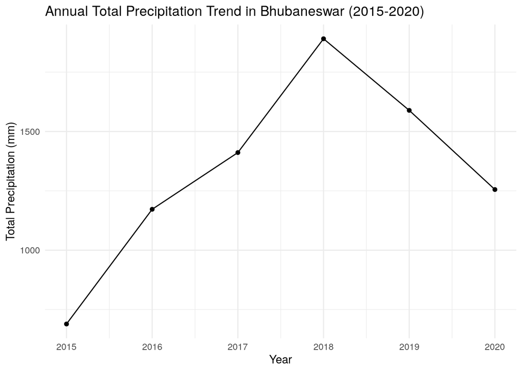

```r
# Precipitation Trend Plot for Bhubaneswar
ggplot(annual_trends_bhubaneswar, aes(x = Year, y = Total_Prcp)) +
    geom_point() +
    geom_line() +
    labs(title = "Annual Total Precipitation Trend in Bhubaneswar (2015-2020)",
         x = "Year",
         y = "Total Precipitation (mm)") +
    theme_minimal()
```

# Comparative Analysis

## Comparing Temperature Data

In this section, we compare the average, minimum, and maximum temperatures among the different cities.

### Average Temperature Comparison

# Ensuring Consistent Structure for Datasets

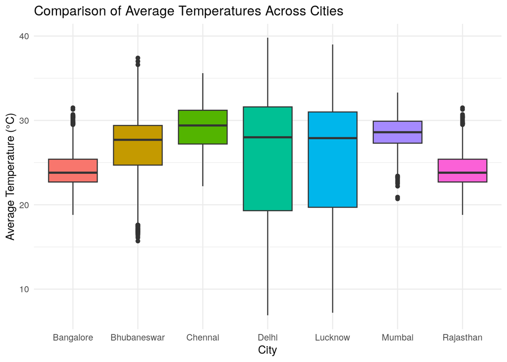

```r
# Select and rename columns (if needed) for each city
bangalore_df <- bangalore_df %>% select(time, tavg, tmin, tmax, prcp) %>% mutate(City = "Bangalore")
chennai_df <- chennai_df %>% select(time, tavg, tmin, tmax, prcp) %>% mutate(City = "Chennai")
delhi_df <- delhi_df %>% select(time, tavg, tmin, tmax, prcp) %>% mutate(City = "Delhi")
lucknow_df <- lucknow_df %>% select(time, tavg, tmin, tmax, prcp) %>% mutate(City = "Lucknow")
mumbai_df <- mumbai_df %>% select(time, tavg, tmin, tmax, prcp) %>% mutate(City = "Mumbai")
rajasthan_df <- rajasthan_df %>% select(time, tavg, tmin, tmax, prcp) %>% mutate(City = "Rajasthan")
bhubaneswar_df <- bhubaneswar_df %>% select(time, tavg, tmin, tmax, prcp) %>% mutate(City = "Bhubaneswar")
rourkela_df <- rourkela_df %>% select(time, tavg, tmin, tmax, prcp) %>% mutate(City = "Rourkela")

# Combine all city datasets into one dataframe
all_cities_df <- rbind(bangalore_df, chennai_df, delhi_df, lucknow_df, mumbai_df, rajasthan_df, bhubaneswar_df, rourkela_df)

# Boxplot for average temperatures
ggplot(all_cities_df, aes(x = City, y = tavg, fill = City)) +
  geom_boxplot() +
  labs(title = "Comparison of Average Temperatures Across Cities",
       x = "City",
       y = "Average Temperature (°C)") +
  theme_minimal() +
  theme(legend.position = "none")
```

# Minimum Temperature Comparison

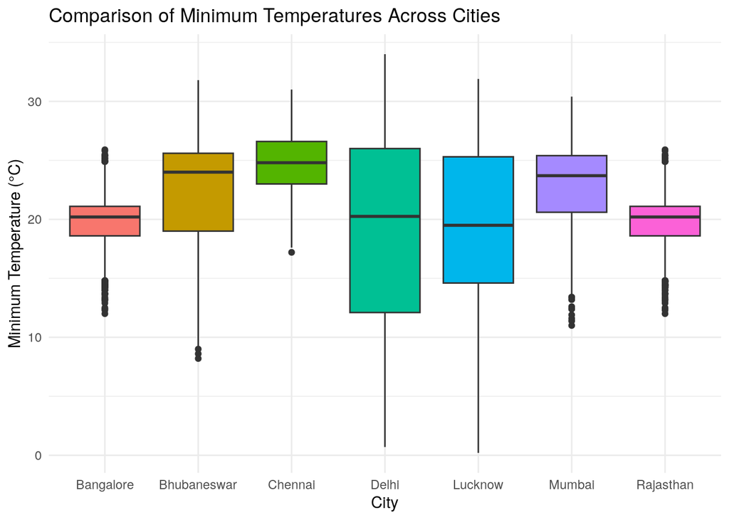

```r
# Boxplot for minimum temperatures
ggplot(all_cities_df, aes(x = City, y = tmin, fill = City)) +
  geom_boxplot() +
  labs(title = "Comparison of Minimum Temperatures Across Cities",
       x = "City",
       y = "Minimum Temperature (°C)") +
  theme_minimal() +
  theme(legend.position = "none")
```

# Maximum Temperature Comparison

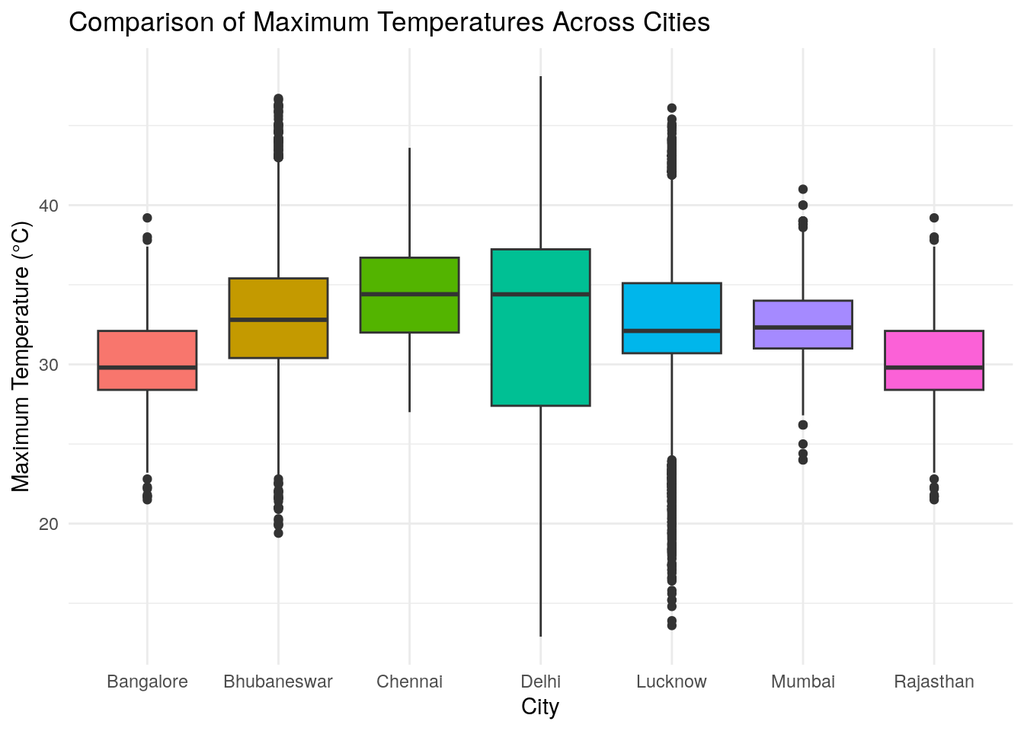

```r
# Boxplot for maximum temperatures
ggplot(all_cities_df, aes(x = City, y = tmax, fill = City)) +
  geom_boxplot() +
  labs(title = "Comparison of Maximum Temperatures Across Cities",
       x = "City",
       y = "Maximum Temperature (°C)") +
  theme_minimal() +
  theme(legend.position = "none")
```

# Comparative Analysis: Precipitation Data Among Cities

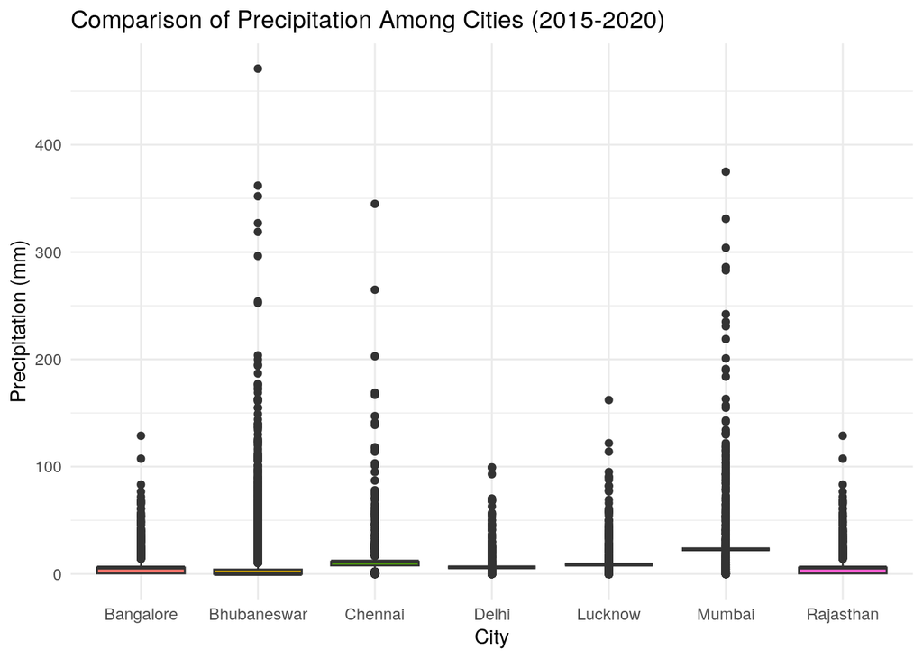

```r
# Creating boxplots for precipitation data
ggplot(all_cities_df, aes(x = City, y = prcp, fill = City)) +
    geom_boxplot() +
    labs(title = "Comparison of Precipitation Among Cities (2015-2020)",
         x = "City",
         y = "Precipitation (mm)") +
    theme_minimal() +
    theme(legend.position = "none")
```

## Year-Over-Year Climate Trends Across Cities

```r
# Calculate annual mean temperatures for each city
annual_mean_temps <- all_cities_df %>%
    group_by(City, Year = format(time, "%Y")) %>%
    summarise(Mean_Tavg = mean(tavg, na.rm = TRUE))
```

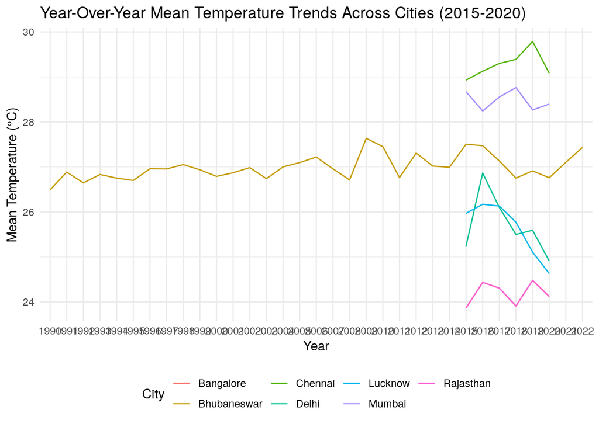

```r
# Plotting the temperature trends
ggplot(annual_mean_temps, aes(x = Year, y = Mean_Tavg, group = City, color = City)) +
    geom_line() +
    labs(title = "Year-Over-Year Mean Temperature Trends Across Cities (2015-2020)",
         x = "Year",
         y = "Mean Temperature (°C)") +
    theme_minimal() +
    theme(legend.position = "bottom")
```

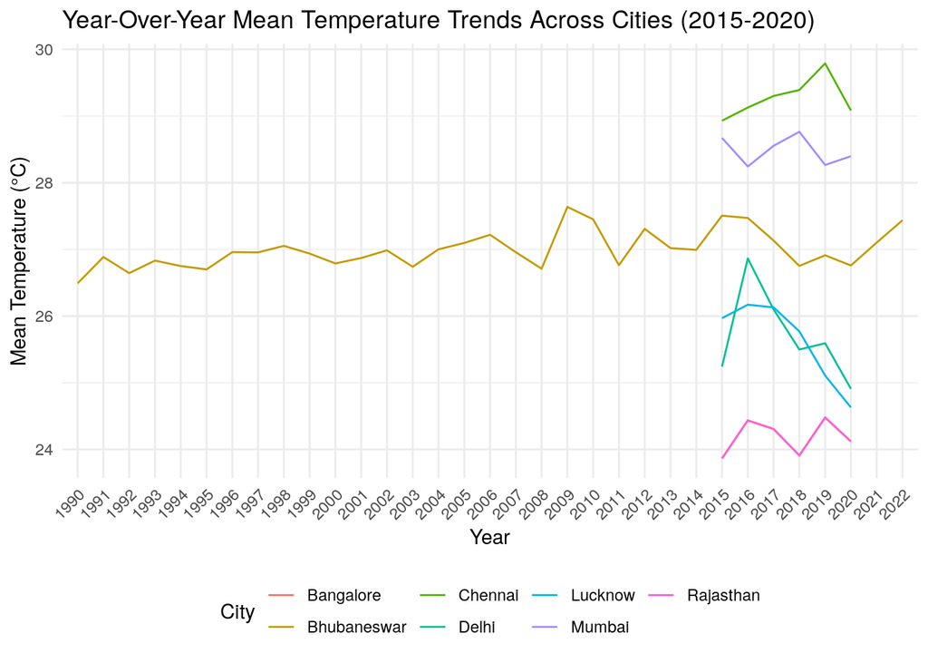

```r
# Plotting temperature trends with improved axis readability
ggplot(annual_mean_temps, aes(x = Year, y = Mean_Tavg, group = City, color = City)) +
    geom_line() +
    labs(title = "Year-Over-Year Mean Temperature Trends Across Cities (2015-2020)",
         x = "Year",
         y = "Mean Temperature (°C)") +
    theme_minimal() +
    theme(legend.position = "bottom") +
    theme(axis.text.x = element_text(angle = 45, hjust = 1)) # Adjusting x-axis labels
```

```r
# Calculate total annual precipitation for each city
annual_precipitation <- all_cities_df %>%
    group_by(City, Year = format(time, "%Y")) %>%
    summarise(Total_Prcp = sum(prcp, na.rm = TRUE))
```

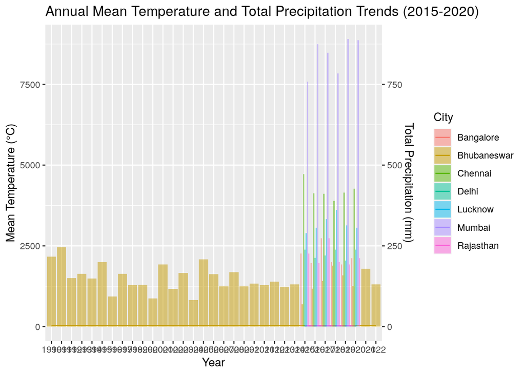

```r
# Base plot with line plot for temperatures
p <- ggplot() +
    geom_line(data = annual_mean_temps, aes(x = Year, y = Mean_Tavg, group = City, color = City)) +
    labs(title = "Annual Mean Temperature and Total Precipitation Trends (2015-2020)",
         x = "Year",
         y = "Mean Temperature (°C)")

# Adding the bar plot for precipitation
p + geom_bar(data = annual_precipitation, aes(x = Year, y = Total_Prcp, fill = City), stat = "identity", position = "dodge", alpha = 0.5) +
    scale_y_continuous(sec.axis = sec_axis(~ . / 10, name = "Total Precipitation (mm)")) # Adjust scale and axis label for precipitation
```

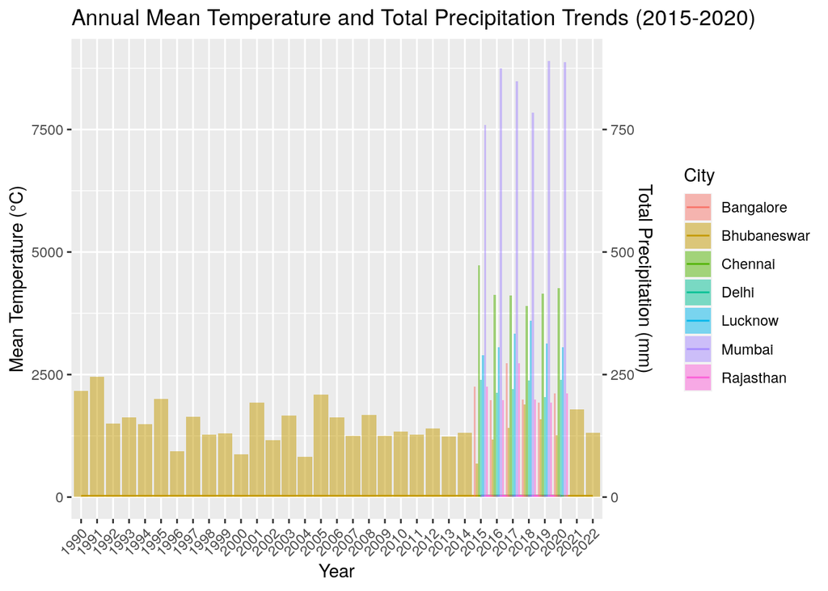

```r
# Base plot with line plot for temperatures
p <- ggplot() +
    geom_line(data = annual_mean_temps, aes(x = Year, y = Mean_Tavg, group = City, color = City)) +
    labs(title = "Annual Mean Temperature and Total Precipitation Trends (2015-2020)",
         x = "Year",
         y = "Mean Temperature (°C)")

# Adding the bar plot for precipitation
p + geom_bar(data = annual_precipitation, aes(x = Year, y = Total_Prcp, fill = City), stat = "identity", position = "dodge", alpha = 0.5) +
    scale_y_continuous(sec.axis = sec_axis(~ . / 10, name = "Total Precipitation (mm)")) +
    theme(axis.text.x = element_text(angle = 45, hjust = 1)) # Rotate x-axis labels
```

## Seasonal Variation Analysis

### Analyzing Seasonal Changes in Temperature and Precipitation

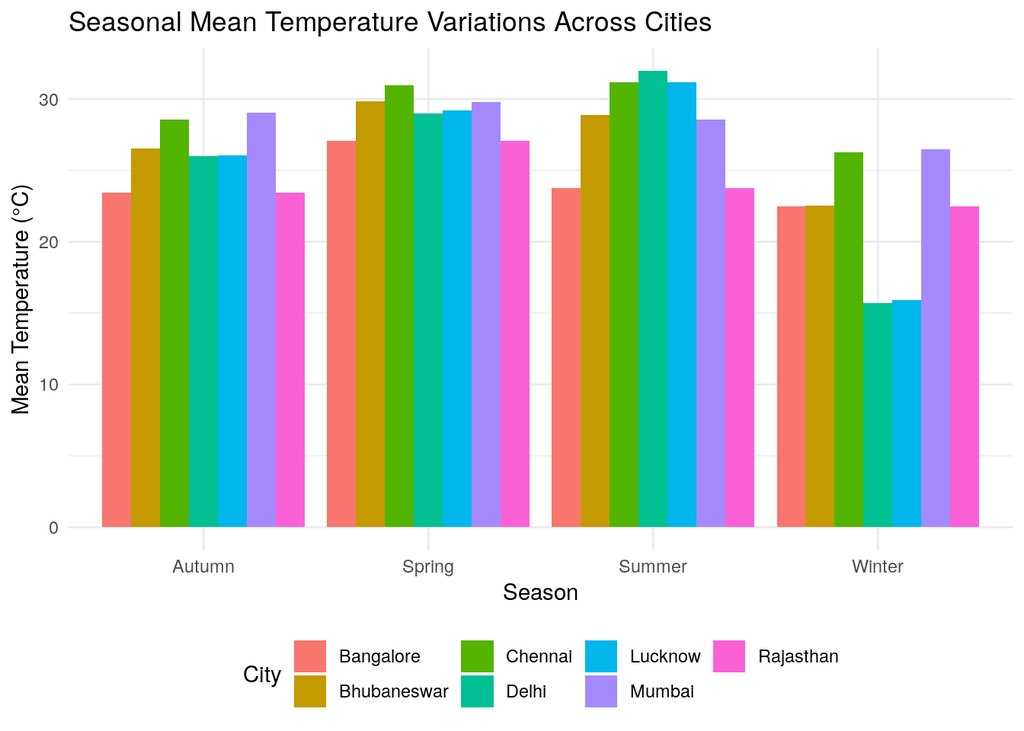

```r
library(dplyr)
library(tidyr)
library(ggplot2)
library(lubridate)

# Function to assign seasons to months
get_season <- function(month) {
  case_when(
    month %in% c(3, 4, 5) ~ "Spring",
    month %in% c(6, 7, 8) ~ "Summer",
    month %in% c(9, 10, 11) ~ "Autumn",
    month %in% c(12, 1, 2) ~ "Winter"
  )
}

# Adding a Season column to the dataset
all_cities_df <- all_cities_df %>%
  mutate(Month = month(time),
         Season = get_season(Month))

# Calculating seasonal mean temperature and total precipitation
seasonal_stats <- all_cities_df %>%
  group_by(City, Season) %>%
  summarise(Mean_Tavg = mean(tavg, na.rm = TRUE),
            Total_Prcp = sum(prcp, na.rm = TRUE), .groups = 'drop')

# Plotting Seasonal Temperature Variations
ggplot(seasonal_stats, aes(x = Season, y = Mean_Tavg, fill = City)) +
  geom_bar(stat = "identity", position = position_dodge()) +
  labs(title = "Seasonal Mean Temperature Variations Across Cities",
       x = "Season",
       y = "Mean Temperature (°C)") +
  theme_minimal() +
  theme(legend.position = "bottom")
```

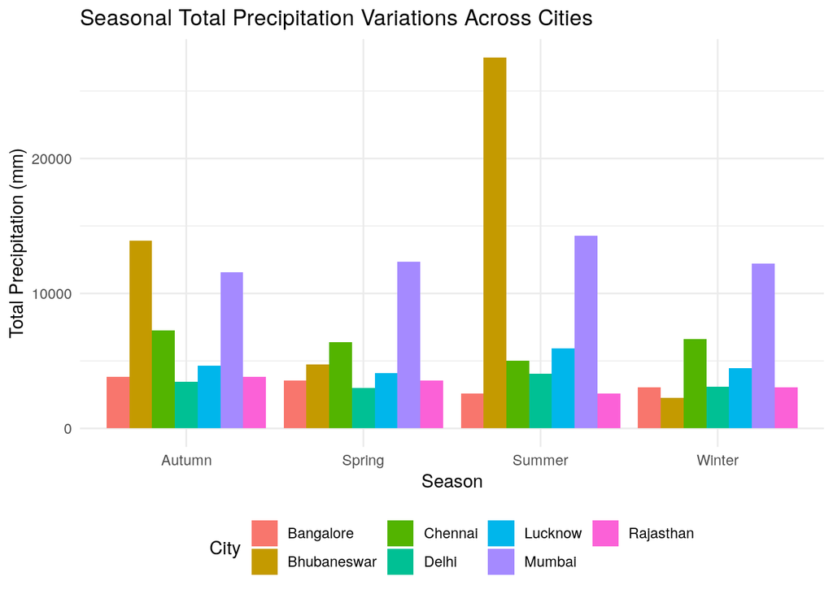

```r
# Plotting Seasonal Precipitation Variations
ggplot(seasonal_stats, aes(x = Season, y = Total_Prcp, fill = City)) +
  geom_bar(stat = "identity", position = position_dodge()) +
  labs(title = "Seasonal Total Precipitation Variations Across Cities",
       x = "Season",
       y = "Total Precipitation (mm)") +
  theme_minimal() +
  theme(legend.position = "bottom")
```

## Correlation Analysis Between Temperature and Precipitation

### Investigating the Relationship Between Average Temperature and Total Precipitation

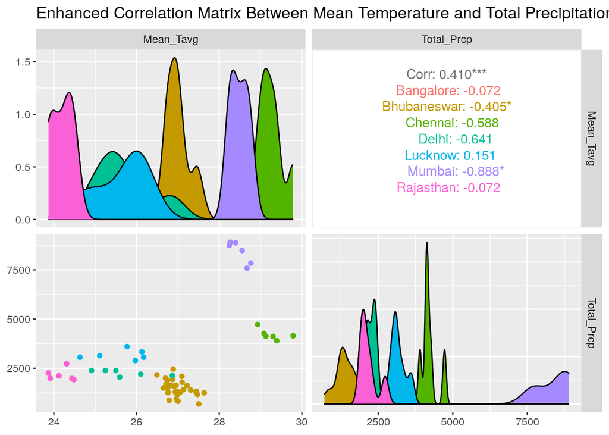

```r
library(dplyr)
library(ggplot2)
library(GGally)
library(DT)

# Calculating annual mean temperature and total precipitation for each city
annual_climate_data <- all_cities_df %>%
  group_by(City, Year = format(time, "%Y")) %>%
  summarise(Mean_Tavg = mean(tavg, na.rm = TRUE),
            Total_Prcp = sum(prcp, na.rm = TRUE), .groups = 'drop')

# Enhanced Correlation Plot
ggpairs(annual_climate_data, columns = c("Mean_Tavg", "Total_Prcp"), ggplot2::aes(colour = City)) +
  labs(title = "Enhanced Correlation Matrix Between Mean Temperature and Total Precipitation Across Cities")
```

```r
# Interactive Table of Correlations
annual_climate_data %>%
  group_by(City) %>%
  summarise(Correlation = cor(Mean_Tavg, Total_Prcp, use = "complete.obs")) %>%
  datatable(options = list(pageLength = 10))
```

|  | City | Correlation |
| --- | --- | --- |
| 1 | Bangalore | -0.07206553500989187 |
| 2 | Bhubaneswar | -0.4046670938821565 |
| 3 | Chennai | -0.58760683697019 |
| 4 | Delhi | -0.6413934007758032 |
| 5 | Lucknow | 0.1505238781787183 |
| 6 | Mumbai | -0.8876394839479306 |
| 7 | Rajasthan | -0.07206553500989187 |

# Extreme Weather Events Analysis

1. Setting Thresholds First, define what constitutes an “extreme” event. This might vary based on the city and the type of event (temperature, rainfall, etc.).

For example, you might consider a day with a temperature above the 95th percentile as extremely hot, or a day with rainfall above the 95th percentile as a day of heavy rainfall.

```r
# Define thresholds for extreme events
temperature_threshold <- quantile(all_cities_df$tavg, 0.95, na.rm = TRUE)
rainfall_threshold <- quantile(all_cities_df$prcp, 0.95, na.rm = TRUE)

# Identify extreme temperature events
all_cities_df$extreme_temp <- all_cities_df$tavg > temperature_threshold

# Identify extreme rainfall events
all_cities_df$extreme_rain <- all_cities_df$prcp > rainfall_threshold


# Analyze extreme temperature events
extreme_temp_analysis <- all_cities_df %>%
    group_by(Year = format(time, "%Y"), City) %>%
    summarise(Extreme_Temp_Days = sum(extreme_temp, na.rm = TRUE))
# Analyze extreme rainfall events
extreme_rain_analysis <- all_cities_df %>%
    group_by(Year = format(time, "%Y"), City) %>%
    summarise(Extreme_Rain_Days = sum(extreme_rain, na.rm = TRUE))
```

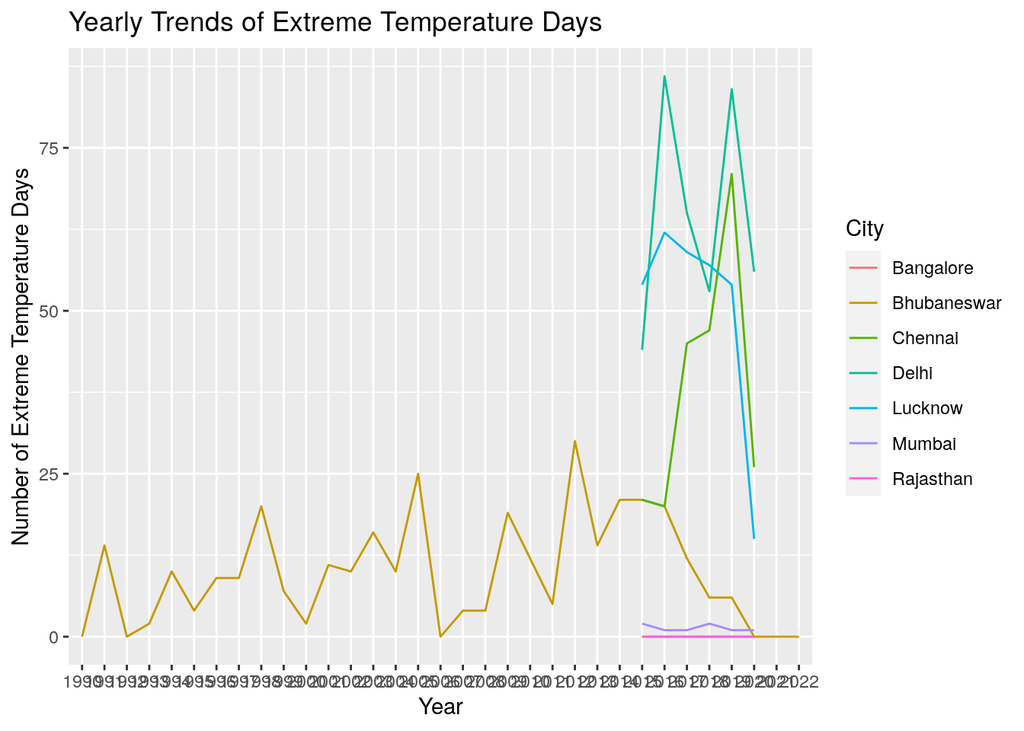

```r
# Plotting extreme temperature trends
ggplot(extreme_temp_analysis, aes(x = Year, y = Extreme_Temp_Days, group = City, color = City)) +
    geom_line() +
    labs(title = "Yearly Trends of Extreme Temperature Days",
         x = "Year",
         y = "Number of Extreme Temperature Days")
```

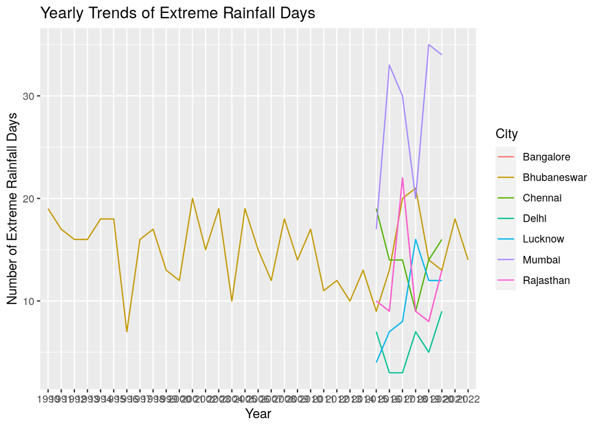

```r
# Plotting extreme rainfall trends
ggplot(extreme_rain_analysis, aes(x = Year, y = Extreme_Rain_Days, group = City, color = City)) +
    geom_line() +
    labs(title = "Yearly Trends of Extreme Rainfall Days",
         x = "Year",
         y = "Number of Extreme Rainfall Days")
```

# Impact of Extreme Weather Events on Specific Months

```r
library(dplyr)
library(lubridate)

# Extract the month from the date
all_cities_df$Month <- format(as.Date(all_cities_df$time), "%m")
all_cities_df$Month <- as.integer(all_cities_df$Month)

# Monthly analysis of extreme temperature events
monthly_extreme_temp <- all_cities_df %>%
    group_by(Month, City) %>%
    summarise(Extreme_Temp_Days = sum(extreme_temp, na.rm = TRUE))
# Monthly analysis of extreme rainfall events
monthly_extreme_rain <- all_cities_df %>%
    group_by(Month, City) %>%
    summarise(Extreme_Rain_Days = sum(extreme_rain, na.rm = TRUE))
```

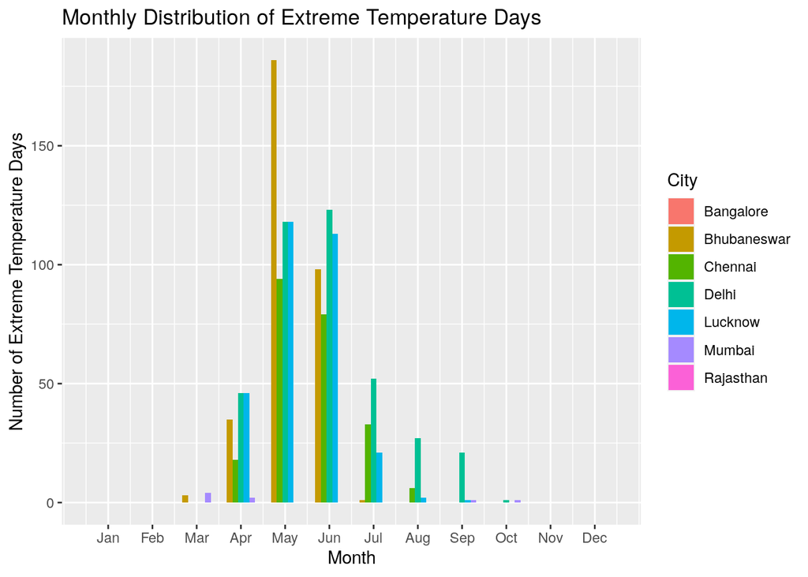

```r
# Plotting monthly extreme temperature trends
ggplot(monthly_extreme_temp, aes(x = Month, y = Extreme_Temp_Days, fill = City)) +
    geom_bar(stat = "identity", position = position_dodge()) +
    labs(title = "Monthly Distribution of Extreme Temperature Days",
         x = "Month",
         y = "Number of Extreme Temperature Days") +
    scale_x_continuous(breaks = 1:12, labels = month.abb)
```

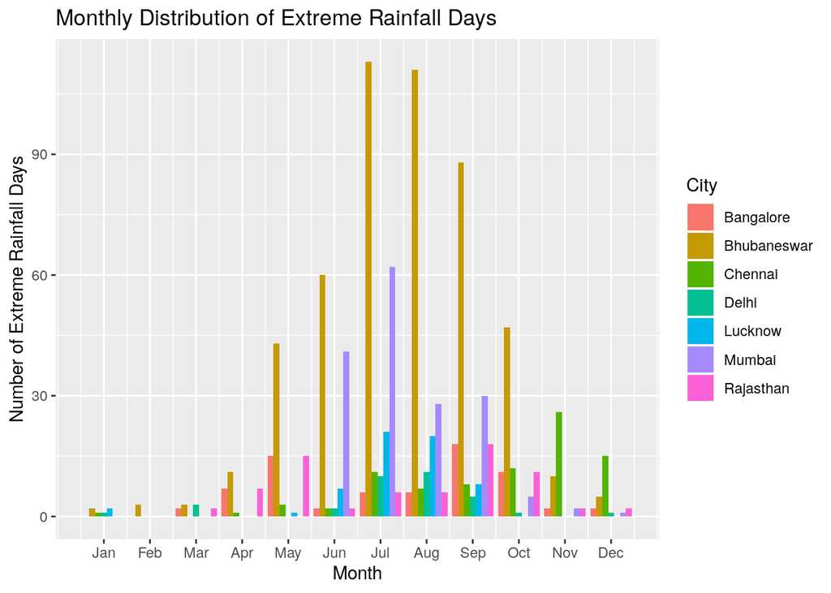

```r
# Plotting monthly extreme rainfall trends
ggplot(monthly_extreme_rain, aes(x = Month, y = Extreme_Rain_Days, fill = City)) +
    geom_bar(stat = "identity", position = position_dodge()) +
    labs(title = "Monthly Distribution of Extreme Rainfall Days",
         x = "Month",
         y = "Number of Extreme Rainfall Days") +
    scale_x_continuous(breaks = 1:12, labels = month.abb)
```

# Long-Term Climate Change Trends Analysis

```r
# Prepare the data for long-term trend analysis
# Ensure all datasets have a Year column

# Add Year column to each city's dataset
bangalore_df$Year <- format(bangalore_df$time, "%Y")
chennai_df$Year <- format(chennai_df$time, "%Y")
delhi_df$Year <- format(delhi_df$time, "%Y")
lucknow_df$Year <- format(lucknow_df$time, "%Y")
mumbai_df$Year <- format(mumbai_df$time, "%Y")
rajasthan_df$Year <- format(rajasthan_df$time, "%Y")
bhubaneswar_df$Year <- format(bhubaneswar_df$time, "%Y")
rourkela_df$Year <- format(rourkela_df$time, "%Y")

# Combine all datasets into one dataframe
all_cities_df <- rbind(
    bangalore_df %>% mutate(City = "Bangalore"),
    chennai_df %>% mutate(City = "Chennai"),
    delhi_df %>% mutate(City = "Delhi"),
    lucknow_df %>% mutate(City = "Lucknow"),
    mumbai_df %>% mutate(City = "Mumbai"),
    rajasthan_df %>% mutate(City = "Rajasthan"),
    bhubaneswar_df %>% mutate(City = "Bhubaneswar"),
    rourkela_df %>% mutate(City = "Rourkela")
)
all_cities_long_term <- all_cities_df %>%
    mutate(Year = as.numeric(Year),
           Decade = case_when(
               Year >= 1990 & Year < 2000 ~ "1990s",
               Year >= 2000 & Year < 2010 ~ "2000s",
               Year >= 2010 & Year <= 2022 ~ "2010s"
           ))

# Decadal temperature trends
decadal_temp_trends <- all_cities_long_term %>%
    group_by(City, Decade) %>%
    summarise(Mean_Tavg = mean(tavg, na.rm = TRUE))
# Decadal precipitation trends
decadal_precip_trends <- all_cities_long_term %>%
    group_by(City, Decade) %>%
    summarise(Total_Prcp = sum(prcp, na.rm = TRUE))
```

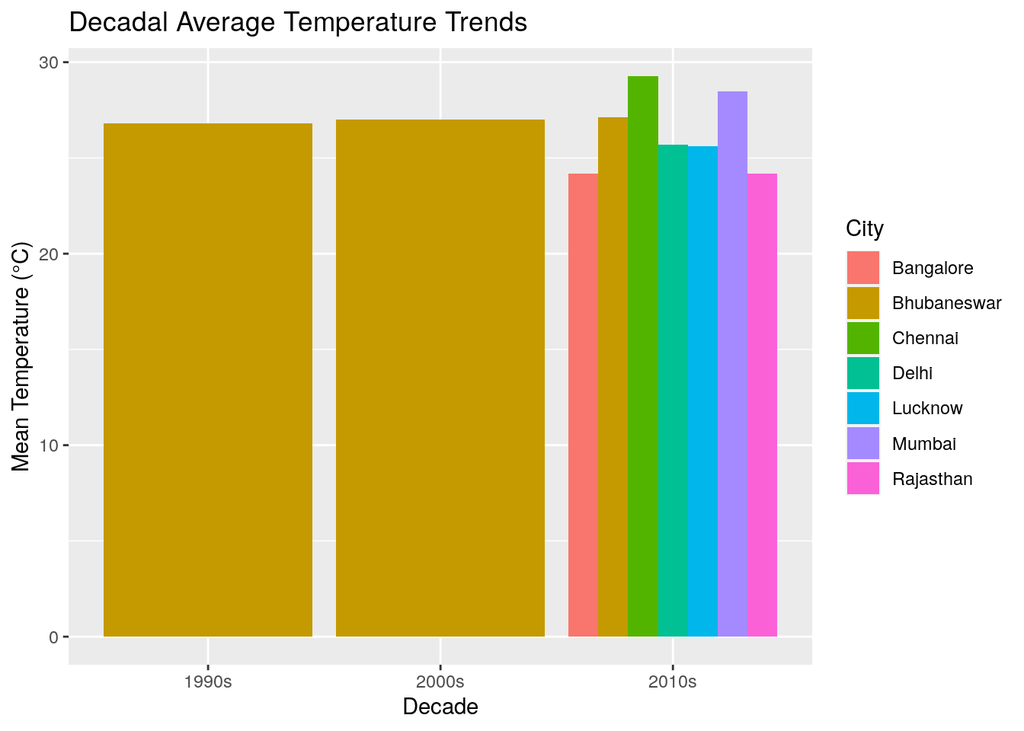

```r
# Temperature trend plot
ggplot(decadal_temp_trends, aes(x = Decade, y = Mean_Tavg, fill = City)) +
    geom_bar(stat = "identity", position = position_dodge()) +
    labs(title = "Decadal Average Temperature Trends",
         x = "Decade",
         y = "Mean Temperature (°C)")
```

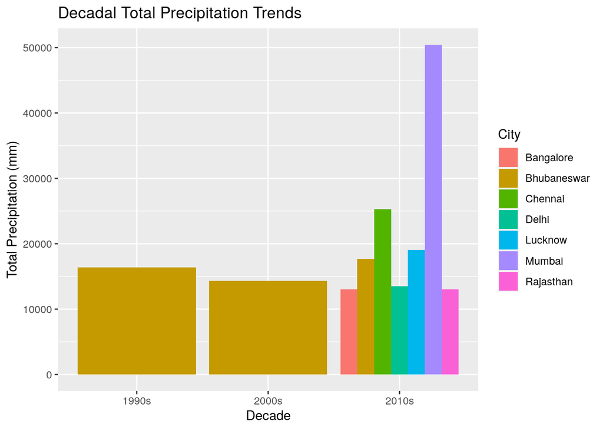

```r
# Precipitation trend plot
ggplot(decadal_precip_trends, aes(x = Decade, y = Total_Prcp, fill = City)) +
    geom_bar(stat = "identity", position = position_dodge()) +
    labs(title = "Decadal Total Precipitation Trends",
         x = "Decade",
         y = "Total Precipitation (mm)")
```

# Analysis and Interpretation

Temperature Trends: Look for upward or downward trends in average temperatures across decades. An increasing trend might indicate warming. Precipitation Trends: Analyze changes in total precipitation over the decades. Changes might indicate shifting patterns in rainfall. 5. Additional Considerations Variability Between Cities: Different cities may show different trends due to their geographic and climatic differences. Limitations: Remember that while this analysis can indicate trends, it doesn’t prove causation. Climatic changes are influenced by a multitude of factors. By comparing decadal averages and totals, you can get a snapshot of how climate parameters have evolved over the past 30 years, offering insights into potential long-term climate change trends.

# Feature Engineering for Rainfall Prediction

```r
# Example using Bangalore's data

# Creating new features based on the date
bangalore_df <- bangalore_df %>%
                mutate(Month = format(time, "%m"),
                       Day = format(time, "%d"),
                       DayOfYear = yday(time))

# Removing the original 'time' column
bangalore_df <- select(bangalore_df, -time)


# Splitting the data into training and testing sets
# Assuming 80% training, 20% testing split

set.seed(123) # For reproducibility
training_indices <- sample(1:nrow(bangalore_df), 0.8 * nrow(bangalore_df))

train_data <- bangalore_df[training_indices, ]
test_data <- bangalore_df[-training_indices, ]

library(randomForest)
# Using Random Forest for rainfall prediction
rf_model <- randomForest(prcp ~ ., data = train_data)

# Summarizing the model
print(rf_model)
```

```
##
## Call:
##  randomForest(formula = prcp ~ ., data = train_data)
##                Type of random forest: regression
##                      Number of trees: 500
## No. of variables tried at each split: 2
##
##           Mean of squared residuals: 80.49238
##                     % Var explained: 9.4
```

```r
# Making predictions on the test data
predictions <- predict(rf_model, test_data)

# Using Mean Absolute Error (MAE) for evaluation
mae <- mean(abs(predictions - test_data$prcp))
print(paste("Mean Absolute Error: ", mae))
```

```
## [1] "Mean Absolute Error:  3.79870041260058"
```

Interpretation of the Results: Mean of Squared Residuals: This is about 80.49, which gives a sense of the average squared difference between the observed actual outcomes and the values predicted by the model.

Percentage of Variance Explained: The model explains around 9.4% of the variance in the rainfall data. This is relatively low, suggesting that the model might not be capturing all the complexities and patterns in the rainfall data.

Mean Absolute Error (MAE): An MAE of 3.80 suggests that, on average, the model’s predictions are about 3.80 units (presumably millimeters if the rainfall is measured that way) away from the actual values.